# Eighth Week: Text Analysis in R

To be, or not to be

Kimia Hamidieh (95109434)

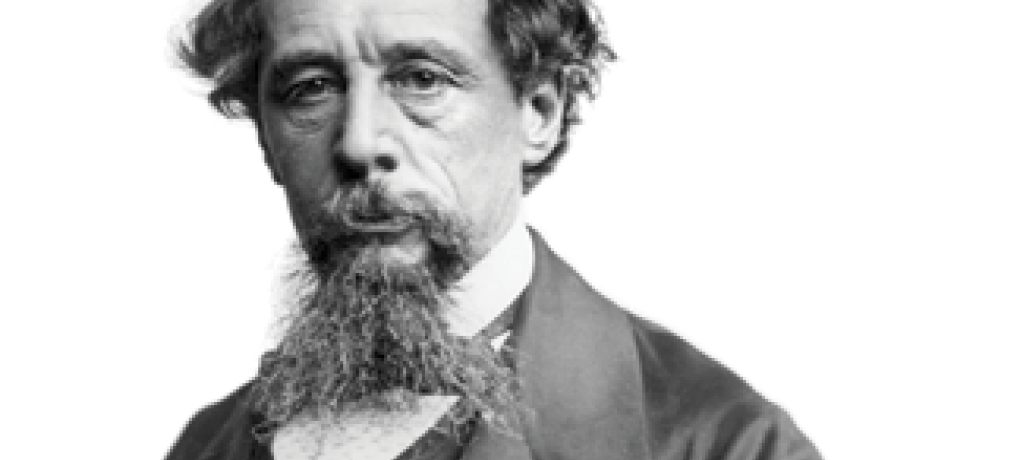

> با استفاده از بسته gutenberg داده های لازم را به دست آورید و به سوالات زیر پاسخ دهید.

۱. چارلز دیکنز نویسنده معروف انگلیسی بالغ بر چهارده رمان (چهارده و نیم) نوشته است. متن تمامی کتاب های او را دانلود کنید و سپس بیست لغت برتر استفاده شده را به صورت یک نمودار ستونی نمایش دهید. (طبیعتا باید ابتدا متن را پاکسازی کرده و stopping words را حذف نمایید تا به کلماتی که بار معنایی مشخصی منتقل می کنند برسید.)

```r
ThePickwickPapers = gutenberg_download(580, meta_fields = "title")
OliverTwist = gutenberg_download(730, meta_fields = "title")
NicholasNickleby = gutenberg_download(967, meta_fields = "title")
TheOldCuriosityShop = gutenberg_download(700, meta_fields = "title")
BarnabyRudge = gutenberg_download(917, meta_fields = "title")
MartinChuzzlewit = gutenberg_download(968, meta_fields = "title")
DombeyandSon = gutenberg_download(821, meta_fields = "title")
DavidCopperfield =gutenberg_download(766, meta_fields = "title")
BleakHouse = gutenberg_download(1023, meta_fields = "title")
HardTimes = gutenberg_download(786, meta_fields = "title")
LittleDorrit = gutenberg_download(963, meta_fields = "title")
ATaleofTwoCities = gutenberg_download(37, meta_fields = "title")
GreatExpectations = gutenberg_download(1400, meta_fields = "title")
OurMutualFriend = gutenberg_download(883, meta_fields = "title")
TheMCysteryofEdwinDrood =gutenberg_download(564, meta_fields = "title")

dickenslist = list()
dickenslist[[1]] = ThePickwickPapers
dickenslist[[2]] = OliverTwist
dickenslist[[3]] = NicholasNickleby
dickenslist[[4]] = TheOldCuriosityShop
dickenslist[[5]] = BarnabyRudge
dickenslist[[6]] = MartinChuzzlewit
dickenslist[[7]] = DombeyandSon
dickenslist[[8]] = DavidCopperfield
dickenslist[[9]] = BleakHouse
dickenslist[[10]] = HardTimes
dickens <- bind_rows(dickenslist)

# dickens <- gutenberg_download(c(580, 730, 967, 700, 917, 968, 821, 766, 1023, 786, 963, 7869, 1400, 883, 564),

romans = as.character(as.roman(1:100)) %>% tolower()

tidy_dickens <- dickens %>%
  unnest_tokens(word, text) %>%
  mutate(word = str_replace(word, "'s", "")) %>%
  anti_join(stop_words) %>%
  filter(!word %in% romans)

tidy_dickens %>%
  group_by(word) %>%
  summarise(freq = n()) %>%
  arrange(desc(freq)) -> freq_words

hchart(freq_words[1:20, ], "column", hcaes(x = word, y = freq))
```

[interactive chart not shown]

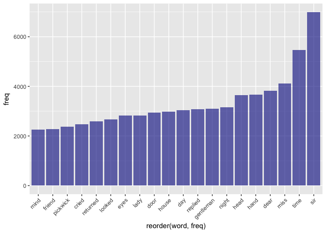

```r
freq_words %>% head(20) %>%
  ggplot(aes(x = reorder(word, freq), y = freq)) +
  geom_col(alpha = 0.6, fill = "dark blue") +
  theme(axis.text.x = element_text(angle = 45, hjust = 1))
```

۲. ابر لغات ۲۰۰ کلمه پرتکرار در رمان های چارلز دیکنز را رسم نمایید. این کار را با بسته wordcloud2 انجام دهید. برای دانلود می توانید به لینک زیر مراجعه کنید.

https://github.com/Lchiffon/wordcloud2

با استفاده از عکسی که در ابتدا متن آمده ابر لغاتی مانند شکل زیر رسم کنید. (راهنمایی: از ورودی figpath در دستور wordcloud2 استفاده نمایید.مثالی در زیر آورده شده است.)

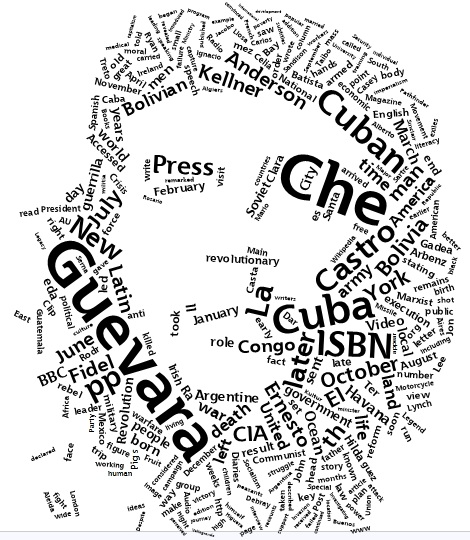

```r
wordcloud2(freq_words, figPath = "images/dickens.png",
           size = 0.4, color = "black")
```

[interactive chart not shown]

۳. اسم پنج شخصیت اصلی در هر رمان دیکنز را استخراج کنید و با نموداری تعداد دفعات تکرار شده بر حسب رمان را رسم نمایید. (مانند مثال کلاس در رسم اسامی شخصیت ها در سری هر پاتر)

```r
dickens_words <- dickens %>% unnest_tokens(word, text, to_lower = FALSE)

dickens_names <- dickens_words %>%
  mutate(word = str_replace(word, "'s|'S", "")) %>%
  filter(!tolower(word) %in% stop_words$word) %>%
  filter(!tolower(word) %in% romans) %>%
  filter(str_detect(word, "[A-Z][a-z]+")) %>%
  filter(!tolower(word) %in% dickens_words$word) %>%
  group_by(word, title) %>%
  summarise(n = n()) %>%
  ungroup() %>%
  group_by(title) %>%
  arrange(desc(n)) %>%
  slice(1:5)

hchart(dickens_names, "bar", hcaes(x = word, y = n, group = title))
```

[interactive chart not shown]

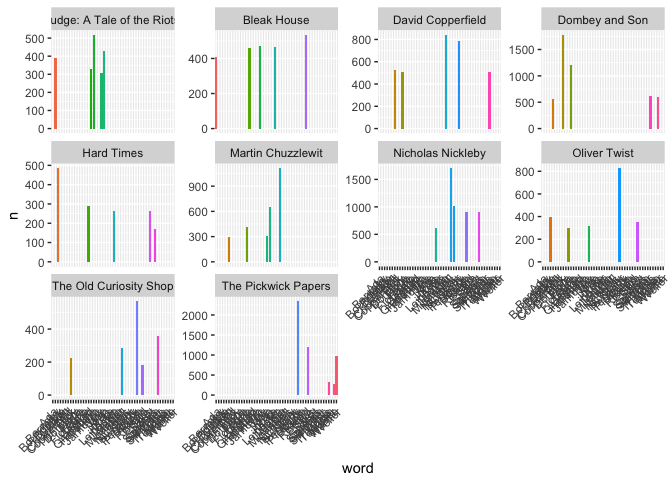

```r
ggplot(dickens_names, aes(x = word, y = n)) +
  geom_col(aes(fill = word), show.legend = FALSE) +
  facet_wrap(~title, scale = "free_y") +
  theme(axis.text.x = element_text(angle = 45, hjust = 1))
```

۴. در بسته tidytext داده ایی به نام sentiments وجود دارد که فضای احساسی لغات را مشخص می نماید. با استفاده از این داده نمودار ۲۰ لغت برتر negative و ۲۰ لغت برتر positive را در کنار هم رسم نمایید. با استفاده از این نمودار فضای حاکم بر داستان چگونه ارزیابی می کنید؟ (به طور مثال برای کتاب داستان دو شهر فضای احساسی داستان به ترتیب تکرر در نمودار زیر قابل مشاهده است.)

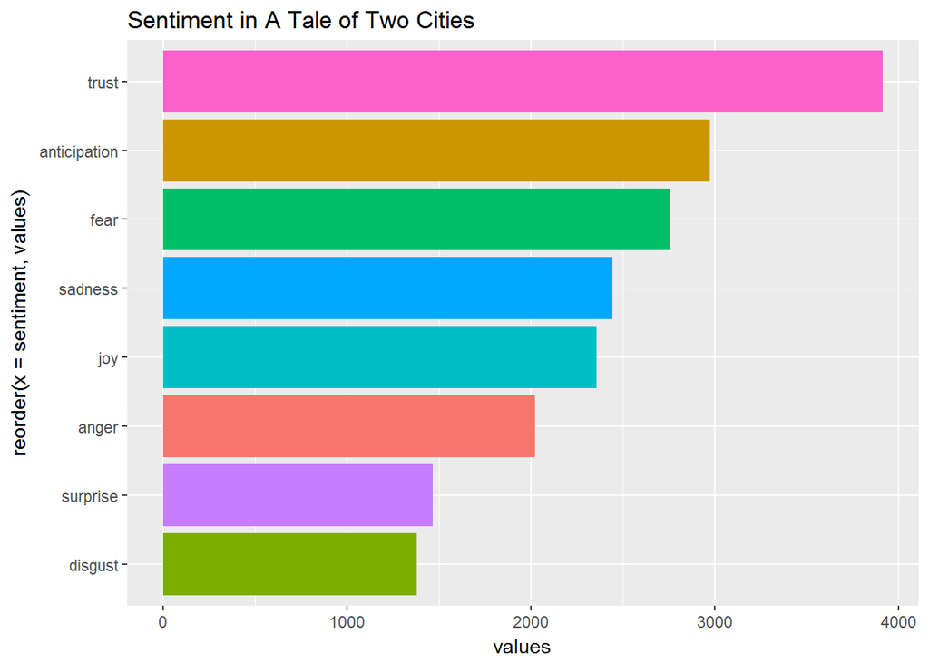

```r
# for all novels -----
sent_words <- tidy_dickens %>%
  inner_join(get_sentiments("bing")) %>%
  count(word, sentiment, sort = TRUE) %>%
  ungroup()

sent_words %>%
  group_by(sentiment) %>%
  slice(1:20) %>%
  ungroup() %>%
  mutate(word = reorder(word, n)) %>%
  hchart("bar", hcaes(x = word, y = n, group = sentiment))
```

[interactive chart not shown]

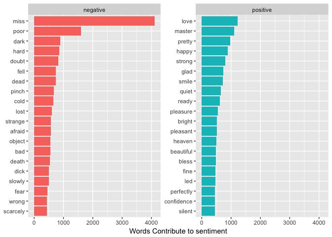

```r
sent_words %>%
  group_by(sentiment) %>%
  slice(1:20) %>%
  ungroup() %>%
  mutate(word = reorder(word, n)) %>%
  ggplot(aes(word, n, fill = sentiment)) +
  geom_col(show.legend = FALSE) +
  facet_wrap(~sentiment, scales = "free_y") +
  labs(y = "Words Contribute to sentiment", x = NULL) +
  coord_flip()
```

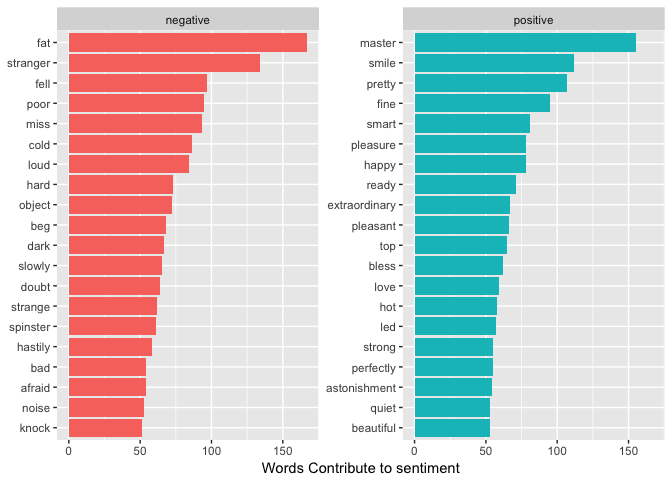

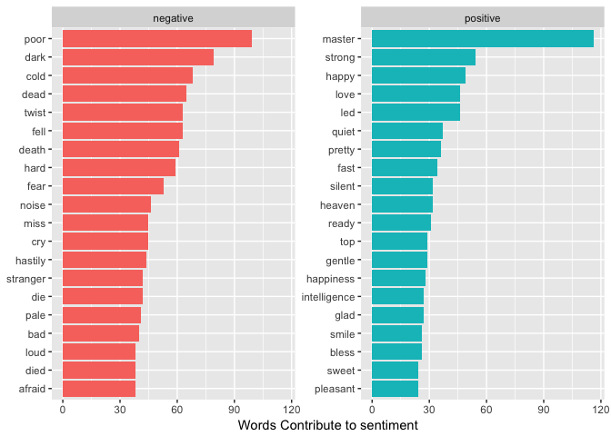

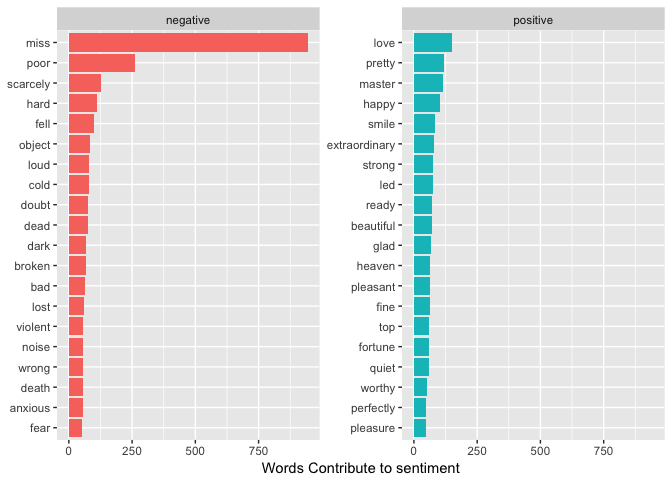

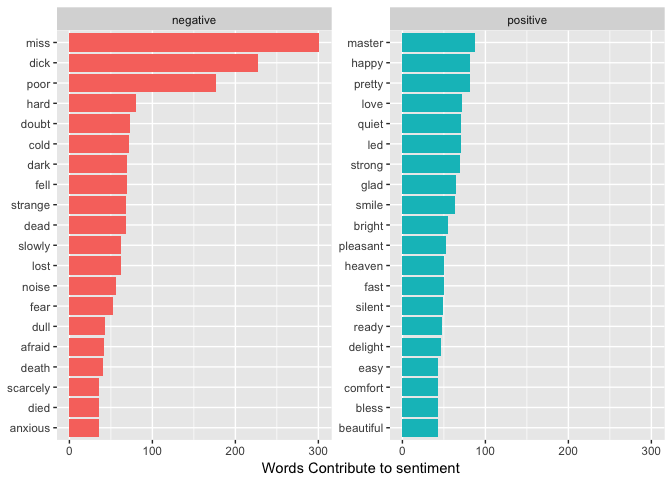

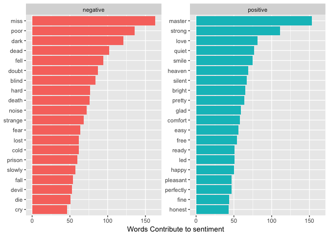

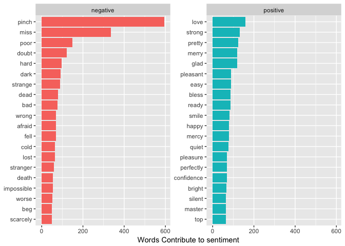

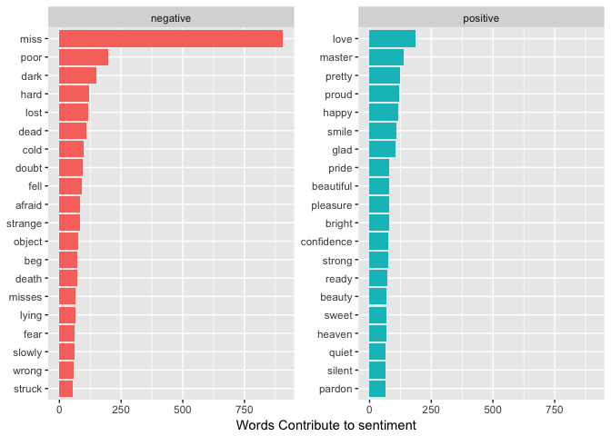

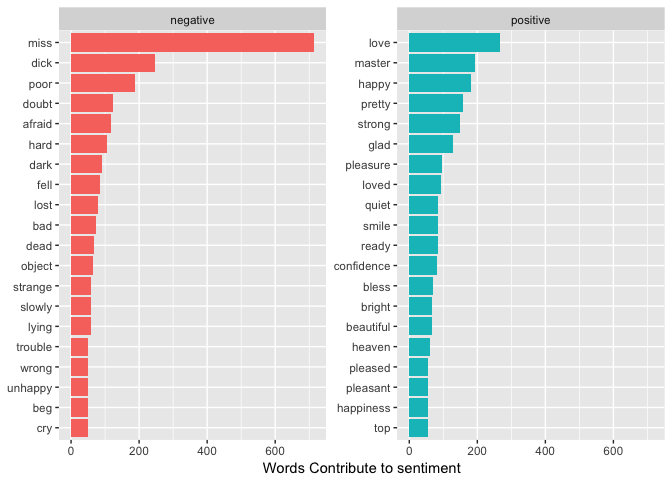

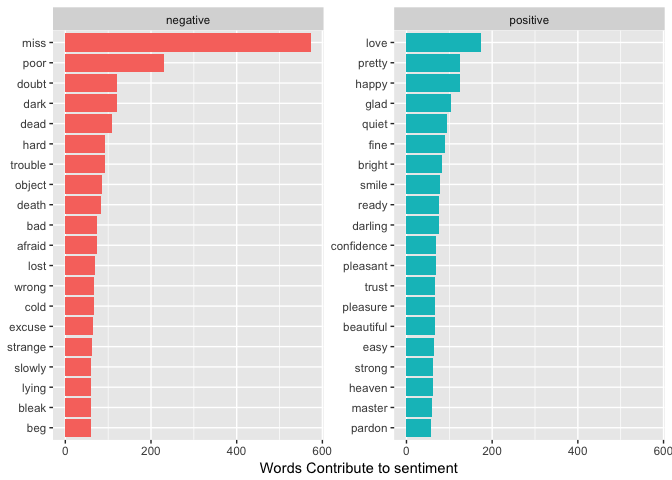

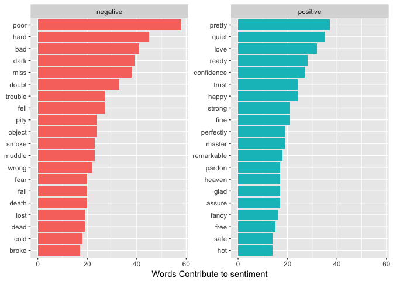

```r
# for each novel -----
for(i in 1:length(dickenslist)) {
  novel <- dickenslist[[i]]
  novel %>%
    group_by() %>%
    unnest_tokens(word, text) %>%
    mutate(word = str_replace(word, "'s", "")) %>%
    anti_join(stop_words) %>%
    filter(!word %in% romans) %>%
    inner_join(get_sentiments("bing")) %>%
    count(word, sentiment, sort = TRUE) %>%
    group_by(sentiment) %>%
    slice(1:20) %>%
    mutate(word = reorder(word, n)) -> novel

    gplot = ggplot(novel, aes(x = reorder(word, n), y = n, fill = sentiment)) +
    geom_col(show.legend = FALSE) +
    facet_wrap(~sentiment, scales = "free_y") +
    labs(y = c("Words Contribute to sentiment", i), x = NULL) +
    coord_flip()
    print(gplot)
    # print(novel$title[1])
}
```

با توجه به نمودارهای رسم شده، می توان دید در اکثر نمودارها لغات منفی بسیار بیشتر از مثبت بوده و بنابراین می توان گفت برای اکثر کتاب ها فضای منفی قالب بوده.

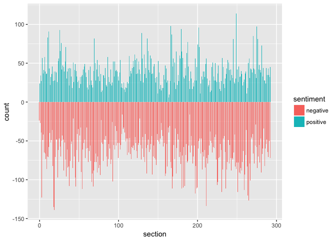

```r
# gutenberg_works(author == "Hugo, Victor") %>% View()

lesmiserables <- gutenberg_download(c(48731, 48732, 48733, 48734, 48735))

numberOfRows = nrow(lesmiserables) / 200

lesmiserables %>%
  mutate(section = floor(row_number() / 200)) %>%
  unnest_tokens(word, text) %>%
  mutate(word = str_replace(word, "'s", "")) %>%
  anti_join(stop_words) %>%
  filter(!word %in% romans) %>%
  inner_join(get_sentiments("bing")) %>%
  group_by(section, sentiment) %>%
  summarise(count = n()) %>%
  mutate(count = ifelse(sentiment == "positive", count, -1 * count)) %>%
  ggplot(aes(x = section, y = count, fill = sentiment)) +
  geom_bar(stat = 'identity', position = position_dodge())
```

۶. ابتدا ترکیبات دوتایی کلماتی که پشت سر هم می آیند را استخراج کنید و سپس نمودار ۳۰ جفت لغت پرتکرار را رسم نمایید.

```r
bigrams_dickens <- dickens %>%
  unnest_tokens(bigram, text, token = "ngrams", n = 2)
bigrams_separated <- bigrams_dickens %>%
  separate(bigram, c("word1", "word2"), sep = " ")

bigram_cnt <- bigrams_separated %>%
  filter(!word1 %in% stop_words$word) %>%
  filter(!word2 %in% stop_words$word) %>%
  count(word1, word2, sort = TRUE) %>%
  mutate(word = paste(word1, word2, " "))

hchart(bigram_cnt[1:30, ], "column", hcaes(x = word, y = n))
```

[interactive chart not shown]

۷. جفت کلماتی که با she و یا he آغاز می شوند را استخراج کنید. بیست فعل پرتکراری که زنان و مردان در داستان های دیکنز انجام می دهند را استخراج کنید و نمودار آن را رسم نمایید.

با توجه به این که کلمه های به دست آمده همگی فعل هایی هستند که باید در stop words باشند و احتمالاً برای she و he به طور یکسان آمده اند، از نسبت log2(she / he) برای به دست آوردن کلمه هایی که برای آن ها به کار رفته شده استفاده می کنیم.

```r
mf_verbs <- bigrams_separated %>%
  filter(word1 == "she" | word1 == "he") %>%
  filter(!word2 %in% stopwords("english")) %>%
  count(word1, word2, sort = TRUE)

hchart(mf_verbs %>% group_by(word1) %>% top_n(20), "column", hcaes(x = word2, y = n, group = word1))
```

[interactive chart not shown]

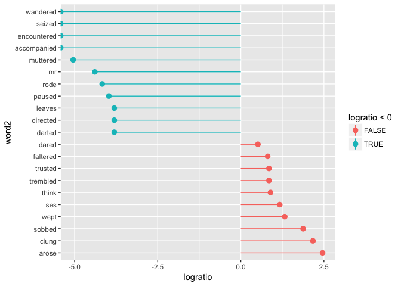

```r
mf_verbs %>%
  group_by(word2) %>%
  filter(sum(n) > 10) %>%
  ungroup() %>%
  spread(word1, n, fill = 0) %>%
  mutate(logratio = log2(she / he)) %>%
  arrange(desc(logratio)) %>%
  mutate(abslogratio = abs(logratio)) %>%
  group_by(logratio < 0) %>%
  top_n(10, abslogratio) %>%
  ungroup() %>%
  arrange(desc(logratio)) %>%
  mutate(word2 = fct_inorder(word2, ordered = TRUE)) %>%
  ggplot(aes(x = word2, y = logratio, color = logratio < 0)) +
  geom_pointrange(aes(ymin = 0, ymax = logratio)) +
  coord_flip()
```

۸. برای کتاب های دیکنز ابتدا هر فصل را جدا کنید. سپی برای هر فصل 1-gram, 2-gram را استخراج کنید. آیا توزیع N-gram در کارهای دیکنز یکسان است؟ با رسم نمودار هم این موضوع را بررسی کنید.

ابتدا 1-grams و 2-grams را به دست می آوریم. سپس برای هر یک از نمونه هایش، برای هر chapter درصد هر n-gram را به دست می آوریم (تعداد تکرار آن n-gram در chapter به کل n-gram های chapter) و نمودار چندتای برتر را رسم می کنیم.

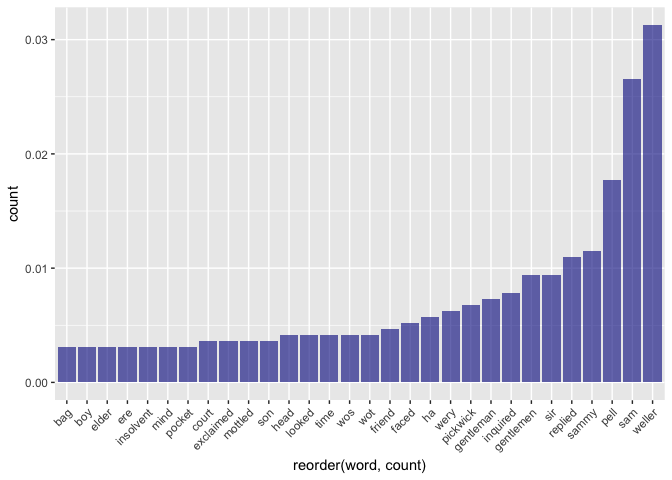

```r
dickens_chap <- dickens %>%
  mutate(linenumber = row_number(),
         chapter = cumsum(str_detect(text, regex("^chapter [\\divxlc]", ignore_case = TRUE))))

# n = 1
dickens_unigram <- dickens_chap %>%
  unnest_tokens(word, text) %>%
  filter(!word %in% stop_words$word) %>%
  filter(!word %in% romans) %>%
  group_by(chapter, gutenberg_id) %>%
  mutate(wordsPerChap = n())

unigram_distr <- dickens_unigram %>%
  filter(word != "NA") %>%
  group_by(gutenberg_id, chapter, word) %>%
  summarise(count = n() / mean(wordsPerChap)) %>%
  mutate(rank = rank(-count, ties.method = "first"))

unigram_distr %>%
  filter(gutenberg_id == 580 , chapter == 100) %>%
  arrange(desc(count)) %>% slice(1:30) %>%
  ggplot(aes(x = reorder(word, count) , y = count)) +
  geom_bar(stat = "identity", fill = "dark blue", alpha = 0.6) +
  theme(axis.text.x = element_text(angle = 45, vjust = 1, hjust = 1))
```

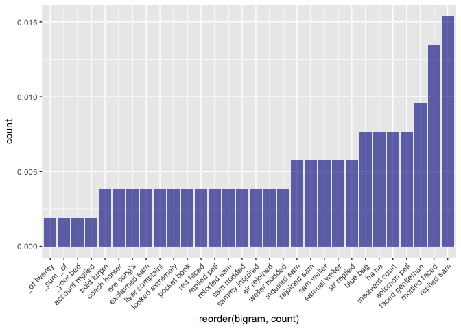

```r
# n = 2
dickens_bigram <- dickens_chap %>%
  unnest_tokens(bigram, text, token = "ngrams", n = 2)

bigrams_separated <- dickens_bigram %>%
  separate(bigram, c("word1", "word2"), sep = " ") %>%
  filter(!(word1 %in% stop_words$word)) %>%
  filter(!(word2 %in% stop_words$word))

# with omited stop words
bigrams_united <- bigrams_separated %>%
  unite(bigram, word1, word2, sep = " ") %>%
  filter(bigram != "NA NA") %>%
  group_by(chapter, gutenberg_id) %>%
  mutate(wordsPerChap = n())

bigram_distr <- bigrams_united %>%
  group_by(gutenberg_id, chapter, bigram) %>%
  summarise(count = n() / mean(wordsPerChap)) %>%
  mutate(rank = rank(-count, ties.method = "first"))

bigram_distr %>%
  filter(gutenberg_id == 580, chapter == 100) %>%
  arrange(desc(count)) %>% slice(1:30) %>%
  ggplot(aes(x = reorder(bigram, count) , y = count)) +
  geom_bar(stat = "identity", fill = "dark blue", alpha = 0.6) +
  theme(axis.text.x = element_text(angle = 45, vjust = 1, hjust = 1))
```

```r
# n = 3
dickens_chap %>%
  unnest_tokens(trigram, text, token = "ngrams", n = 3) %>%
  separate(trigram, c("word1", "word2", "word3"), sep = " ") %>%
  drop_na() %>%
  filter(!word1 %in% stop_words$word,
         !word2 %in% stop_words$word,
         !word3 %in% stop_words$word) -> trigram_seprated

trigram_united <- trigram_seprated %>% unite(trigram, word1, word2, word3, sep = " ")
```

۹. برای آثار ارنست همینگوی نیز تمرین ۸ را تکرار کنید. آیا بین آثار توزیع n-grams در بین آثار این دو نویسنده یکسان است؟

```r
# gutenberg_works(author == "Austen, Jane") %>% View()
austen <- gutenberg_download(c(105, 121, 141, 158, 161, 946, 1342), meta_fields = "title")

# rep 8 for austen ---------
austen_chap <- austen %>%
  mutate(linenumber = row_number(),
         chapter = cumsum(str_detect(text, regex("^chapter [\\divxlc]", ignore_case = TRUE))))

# n = 1
austen_unigram <- austen_chap %>%
  unnest_tokens(word, text) %>%
  filter(!word %in% stop_words$word) %>%
  filter(!word %in% romans) %>%
  group_by(chapter, gutenberg_id) %>%
  mutate(wordsPerChap = n())

unigram_distr_austen <- austen_unigram %>%
  filter(word != "NA") %>%
  group_by(gutenberg_id, chapter, word) %>%
  summarise(count = n() / mean(wordsPerChap)) %>%
  mutate(rank = rank(-count, ties.method = "first"))

# n = 2
austen_bigram <- austen_chap %>%
  unnest_tokens(bigram, text, token = "ngrams", n = 2)

bigrams_separated_austen <- austen_bigram %>%
  separate(bigram, c("word1", "word2"), sep = " ") %>%
  filter(!(word1 %in% stop_words$word)) %>%
  filter(!(word2 %in% stop_words$word))

# with omited stop words
bigrams_united_austen <- bigrams_separated_austen %>%
  unite(bigram, word1, word2, sep = " ") %>%
  filter(bigram != "NA NA") %>%
  group_by(chapter, gutenberg_id) %>%
  mutate(wordsPerChap = n())

bigram_distr_austen <- bigrams_united_austen %>%
  group_by(gutenberg_id, chapter, bigram) %>%
  summarise(count = n() / mean(wordsPerChap)) %>%
  mutate(rank = rank(-count, ties.method = "first"))
```

ابتدا تمام توزیع 1-gram و 2-gram ها را همانند سوال قبل برای رمان های جین آستین به دست می آوریم. سپس برای بررسی این که آیا توزیع n-gram ها بین آثار این دو نویشنده یکی است یا خیر، ابتدا برای هردو این رمان ها، 1-gram و 2-gram های برتر (با تعداد بیشتر) را به دست می آوریم. سپس، آن ها را در bikeywords و unikeywords ذخیره می کنیم تا برای قسمت بعد برای انتخاب ستون های train و test نیز به آن ها دسترسی داشته باشیم. حال برای رمان های این دو نویسنده، تعداد تمام این n-gram ها را با استفاده از دیتافریم هایی که قبلاً ساخته بودیم به دست می آوریم. بنابراین ماتریسی خواهیم داشت که به ازای هر n-gram، مقدار آن را در توزیع دیکنز و آستین نشان می دهد. با توجه به این که نویسنده ها و n-gramها categorial هستند، از آزمون فرض chi-squared استفاده می کنیم.

```r
# chisq -----------

bound = 30

bigrams_united %>%
  filter(bigram != "NA NA") %>%
  group_by(bigram) %>%
  summarise(n1 = n()) %>%
  arrange(desc(n1)) %>%
  slice(1:bound) -> dickens_biwords
bigrams_united_austen %>%
  filter(bigram != "NA NA") %>%
  group_by(bigram) %>%
  summarise(n2 = n()) %>%
  arrange(desc(n2)) %>%
  slice(1:bound) -> austen_biwords
bikeywords <- full_join(dickens_biwords, austen_biwords)
bikeywords[is.na(bikeywords)] = 0

dickens_unigram %>%
  filter(word != "NA") %>%
  group_by(word) %>%
  summarise(n1 = n()) %>%
  arrange(desc(n1)) %>%
  slice(1:bound) -> dickens_uniwords
austen_unigram %>%
  filter(word != "NA") %>%
  group_by(word) %>%
  summarise(n2 = n()) %>%
  arrange(desc(n2)) %>%
  slice(1:bound) -> austen_uniwords
unikeywords <- full_join(dickens_uniwords, austen_uniwords)
unikeywords[is.na(unikeywords)] = 0

mat = full_join(bigrams_united %>%
            filter(bigram %in% bikeywords$bigram) %>%
            group_by(bigram) %>%
            summarise(count1 = mean(wordsPerChap, na.rm = T)),
          bigrams_united_austen %>%
            filter(bigram %in% bikeywords$bigram) %>%
            group_by(bigram) %>%
            summarise(count2 = mean(wordsPerChap, na.rm = T)), by = "bigram", all.x = TRUE) %>%
  # mutate(count1 = ifelse(is.na(count1), 0, count1)) %>%
  # mutate(count2 = ifelse(is.na(count2), 0, count2)) %>%
  select(-bigram) %>% as.matrix()
mat[is.na(mat)] = 0
mat = mat[-nrow(mat), ]

chisq.test(mat)
```

```
##
##  Pearson's Chi-squared test
##
## data:  mat
## X-squared = 63905, df = 57, p-value < 2.2e-16
```

با توجه به مقدار به دست آمده برای آزمون فرض می توان گفت n-gram ها در تشخیص نویسنده بسیار به کار می آیند. (این آزمون فقط برای 2-gram به دست آمده، به همین ترتیب برای 1-gram قابل انجام است.)

۱۰. بر اساس دادهایی که در تمرین ۸ و ۹ از آثار دو نویسنده به دست آوردید و با استفاده از N-gram ها یک مدل لاجستیک برای تشخیص صاحب اثر بسازید. خطای مدل چقدر است؟ برای یادگیری مدل از کتاب کتاب الیور تویست اثر دیکنز و کتاب پیرمرد و دریا استفاده نکنید. پس از ساختن مدل برای تست کردن فصل های این کتابها را به عنوان داده ورودی به مدل بدهید. خطای تشخیص چقدر است؟

دیتافریم train را به این گونه می سازیم که نمونه های ما، سطرهایی از مقدار توزیع n-gramها در هر فصل و کتابند. و خروجی ۰ یا ۱ برای دیکنز یا آستن.

```r
bigram_distr %>%
  filter(gutenberg_id != 730) %>%
  filter(bigram %in% bikeywords$bigram) %>%
  select(gutenberg_id, chapter, bigram, count) %>%
  spread(key = bigram, value = count) -> train_dickens_bi
unigram_distr %>%
  filter(gutenberg_id != 730) %>%
  filter(word %in% unikeywords$word) %>%
  select(gutenberg_id, chapter, word, count) %>%
  spread(key = word, value = count) -> train_dickens_uni
train_dickens = inner_join(train_dickens_bi, train_dickens_uni, by = c("gutenberg_id", "chapter")) %>%
  ungroup() %>%
  select(-c(gutenberg_id, chapter))
train_dickens[is.na(train_dickens)] = 0
train_dickens$author = 1 # dickens : y = 1

bigram_distr_austen %>%
  filter(gutenberg_id != 1342) %>%
  filter(bigram %in% bikeywords$bigram) %>%
  select(gutenberg_id, chapter, bigram, count) %>%
  spread(key = bigram, value = count) -> train_austen_bi
unigram_distr_austen %>%
  filter(gutenberg_id != 1342) %>%
  filter(word %in% unikeywords$word) %>%
  select(gutenberg_id, chapter, word, count) %>%
  spread(key = word, value = count) -> train_austen_uni
train_austen = inner_join(train_austen_bi, train_austen_uni, by = c("gutenberg_id", "chapter")) %>%
  ungroup() %>%
  select(-c(gutenberg_id, chapter))
train_austen[is.na(train_austen)] = 0
train_austen$author = 0 # austen : y = 0

plyr::rbind.fill(train_austen, train_dickens) -> train
train[is.na(train)] = 0
```

حال با استفاده از کتابخانه ی h20، می توان روی این دیتافریم، مدلی لاجستیک برای تشخیص خروجی binomial (نویسنده) ساخت. که همان طور که در summary مدل آمده است، پارامترهای خطای آن مانند MSE، RMSE، LogLoss، Residual deviance و … همگی مقادیری مناسب دارند و می توان گفت مدل خوبی به دست آمده است.

```r
library(h2o)
h2o.init()
```

[output not shown]

```r
htrain = as.h2o(train)
colnames_train = colnames(train %>% select(-author))
hglm = h2o.glm(y = "author", x = colnames_train,
               training_frame = htrain, family = "binomial")
# model error
summary(hglm)
```

```
## Model Details:
## ==============
##
## H2OBinomialModel: glm
## Model Key:  GLM_model_R_1525600638344_19
## GLM Model: summary
##     family  link                               regularization
## 1 binomial logit Elastic Net (alpha = 0.5, lambda = 0.05537 )
##   number_of_predictors_total number_of_active_predictors
## 1                        105                          36
##   number_of_iterations training_frame
## 1                    5          train
##
## H2OBinomialMetrics: glm
## ** Reported on training data. **
##
## MSE:  0.02057997
## RMSE:  0.1434572
## LogLoss:  0.1199357
## Mean Per-Class Error:  0.00245098
## AUC:  0.9999886
## Gini:  0.9999773
## R^2:  0.9056189
## Residual Deviance:  152.3183
## AIC:  226.3183
##
## Confusion Matrix (vertical: actual; across: predicted) for F1-optimal threshold:
##          0   1    Error    Rate
## 0      203   1 0.004902  =1/204
## 1        0 431 0.000000  =0/431
## Totals 203 432 0.001575  =1/635
##
## Maximum Metrics: Maximum metrics at their respective thresholds
##                         metric threshold    value idx
## 1                       max f1  0.538982 0.998841 234
## 2                       max f2  0.538982 0.999536 234
## 3                 max f0point5  0.615251 0.999535 232
## 4                 max accuracy  0.615251 0.998425 232
## 5                max precision  0.998869 1.000000   0
## 6                   max recall  0.538982 1.000000 234
```

[output cut: 29 more lines]

```
##      names coefficients sign
## 1     head     0.507900  POS
## 2 feelings     0.405105  NEG
## 3     till     0.359717  NEG
## 4     hand     0.357736  POS
## 5     emma     0.320181  NEG
##
## ---
##                names coefficients sign
## 100      replied sam     0.000000  POS
## 101 single gentleman     0.000000  POS
## 102    sir leicester     0.000000  POS
## 103     sir mulberry     0.000000  POS
## 104     sir returned     0.000000  POS
## 105         pickwick     0.000000  POS
```

سپس داده ی تست را همانند train با کتاب های مربوطه می سازیم. و همانطور که آمده است، درصد خطای تشخیص نویسنده برای این داده، ۲٪ است. که نشان می دهد مدل بسیار خوب جواب می دهد.

```r
bigram_distr %>%
  filter(gutenberg_id == 730) %>%
  filter(bigram %in% bikeywords$bigram) %>%
  select(gutenberg_id, chapter, bigram, count) %>%
  spread(key = bigram, value = count) -> test_dickens_bi
unigram_distr %>%
  filter(gutenberg_id == 730) %>%
  filter(word %in% unikeywords$word) %>%
  select(gutenberg_id, chapter, word, count) %>%
  spread(key = word, value = count) -> test_dickens_uni
test_dickens = inner_join(test_dickens_bi, test_dickens_uni, by = c("gutenberg_id", "chapter")) %>%
  ungroup() %>%
  select(-c(gutenberg_id, chapter))
test_dickens[is.na(test_dickens)] = 0
n_dickens = nrow(test_dickens)


bigram_distr_austen %>%
  filter(gutenberg_id == 1342) %>%
  filter(bigram %in% bikeywords$bigram) %>%
  select(gutenberg_id, chapter, bigram, count) %>%
  spread(key = bigram, value = count) -> test_austen_bi
unigram_distr_austen %>%
  filter(gutenberg_id == 1342) %>%
  filter(word %in% unikeywords$word) %>%
  select(gutenberg_id, chapter, word, count) %>%
  spread(key = word, value = count) -> test_austen_uni
test_austen = inner_join(test_austen_bi, test_austen_uni, by = c("gutenberg_id", "chapter")) %>%
  ungroup() %>%
  select(-c(gutenberg_id, chapter))
test_austen[is.na(test_austen)] = 0
n_austen = nrow(test_austen)

test = full_join(test_dickens, test_austen)

diff = setdiff(colnames_train, colnames(test))
test = cbind(test, setNames(lapply(diff, function(x) x = NA), diff))
test[is.na(test)] <- 0
htest = as.h2o(test)
predict <- as.data.frame(h2o.predict(hglm, htest))
cbind(test, predict %>% select(predict)) -> test

test$answer = integer(nrow(test))
test$answer[1:n_dickens] <- 1

# diagnosis error
sum(test$predict != test$answer) / nrow(test)
```

```
## [1] 0.02173913
```